# Clustering on Customer Hotel Reservation

The objective of this report is to observe behaviour of hotel customers and compare two clustering methods on this dataset( k-medoids/ hierarchical). The dataset refers to a random sample of room reservations at a hotel and whether or not the reservation was ultimately cancelled.

### Dataset Variables

| Variable | Description |
| --- | --- |
| `Booking_ID` | Unique identifier for each booking |
| `number.of.adults` | Number of adults included in the booking |
| `number.of.children` | Number of children included in the booking |
| `number.of.weekend.nights` | Number of weekend nights included in the booking |
| `number.of.week.nights` | Number of week nights included in the booking |
| `type.of.meal` | Type of meal included in the booking |
| `car.parking.space` | Indicates whether a car parking space was requested or included in the booking |
| `room.type` | Type of room booked |
| `lead.time` | Number of days between the booking date and the arrival date |
| `market.segment.type` | Type of market segment associated with the booking |
| `repeated` | Indicates whether the booking is a repeat booking |
| `P.C` | Number of previous bookings canceled by the customer prior to the current booking |
| `P.not.C` | Number of previous bookings not canceled by the customer prior to the current booking |
| `average.price` | Average price associated with the booking |
| `special.requests` | Number of special requests made by the guest |
| `date.of.reservation` | Date of the reservation |
| `booking.status` | Status of the booking (canceled or not canceled) |

#### Dataset : First 10 observations

| Booking_ID | number.of.adults | number.of.children | number.of.weekend.nights | number.of.week.nights | type.of.meal | car.parking.space | room.type | lead.time | market.segment.type | repeated | P.C | P.not.C | average.price | special.requests | date.of.reservation | booking.status |
| --- | --- | --- | --- | --- | --- | --- | --- | --- | --- | --- | --- | --- | --- | --- | --- | --- |
| BID19169 | 2 | 0 | 1 | 0 | Meal Plan 1 | 0 | Room_Type 1 | 0 | Online | 0 | 0 | 0 | 115 | 1 | 43016 | Not_Canceled |
| BID26830 | 2 | 0 | 1 | 4 | Meal Plan 1 | 0 | Room_Type 1 | 11 | Online | 0 | 0 | 0 | 90 | 2 | 8/17/2017 | Canceled |
| BID00278 | 1 | 0 | 2 | 1 | Meal Plan 1 | 0 | Room_Type 1 | 33 | Online | 0 | 0 | 0 | 82.9 | 2 | 43223 | Not_Canceled |
| BID22091 | 2 | 0 | 0 | 1 | Meal Plan 2 | 0 | Room_Type 1 | 55 | Offline | 0 | 0 | 0 | 104 | 0 | 43255 | Not_Canceled |
| BID17706 | 2 | 1 | 0 | 2 | Meal Plan 1 | 0 | Room_Type 1 | 138 | Online | 0 | 0 | 0 | 139.5 | 1 | 43351 | Not_Canceled |
| BID32402 | 3 | 0 | 0 | 3 | Meal Plan 1 | 0 | Room_Type 4 | 160 | Online | 0 | 0 | 0 | 137.7 | 0 | 7/14/2018 | Canceled |
| BID22733 | 1 | 0 | 1 | 1 | Meal Plan 1 | 0 | Room_Type 1 | 3 | Online | 1 | 0 | 1 | 89.5 | 1 | 12/19/2018 | Not_Canceled |
| BID35379 | 2 | 0 | 0 | 3 | Meal Plan 1 | 0 | Room_Type 1 | 107 | Offline | 0 | 0 | 0 | 58 | 0 | 3/17/2018 | Not_Canceled |
| BID18684 | 1 | 0 | 1 | 1 | Meal Plan 1 | 0 | Room_Type 4 | 17 | Online | 0 | 0 | 0 | 114.73 | 1 | 43443 | Not_Canceled |
| BID15576 | 2 | 0 | 0 | 3 | Meal Plan 1 | 0 | Room_Type 1 | 18 | Online | 0 | 0 | 0 | 12 | 2 | 42775 | Not_Canceled |

### 1. Variable Selection

Pearson correlation matrix for numeric variables

|  | number.of.adults | number.of.children | number.of.weekend.nights | number.of.week.nights | lead.time | P.C | P.not.C | special.requests |
| --- | --- | --- | --- | --- | --- | --- | --- | --- |
| number.of.adults | 1.00 | -0.04 | 0.09 | 0.10 | 0.09 | -0.08 | -0.13 | 0.18 |
| number.of.children | -0.04 | 1.00 | 0.00 | 0.02 | -0.04 | -0.02 | -0.02 | 0.15 |
| number.of.weekend.nights | 0.09 | 0.00 | 1.00 | 0.20 | 0.04 | 0.01 | -0.01 | 0.07 |
| number.of.week.nights | 0.10 | 0.02 | 0.20 | 1.00 | 0.13 | -0.06 | -0.06 | 0.05 |
| lead.time | 0.09 | -0.04 | 0.04 | 0.13 | 1.00 | -0.07 | -0.08 | -0.07 |
| P.C | -0.08 | -0.02 | 0.01 | -0.06 | -0.07 | 1.00 | 0.71 | -0.02 |
| P.not.C | -0.13 | -0.02 | -0.01 | -0.06 | -0.08 | 0.71 | 1.00 | 0.05 |
| special.requests | 0.18 | 0.15 | 0.07 | 0.05 | -0.07 | -0.02 | 0.05 | 1.00 |

For variable selection, we first examine the correlations among all numerical variables. If two variables show a high correlation with each other, this indicates that they could potentially be combined.

Furthermore, correlation does not imply causation, since a strong correlation does not mean that one variable causes a change in the other.

Data preparation: Since dataset is mixed, potentially gower distance will be used and string variables should not be transformed to binary. gower computes difference between variables for categorical data.

```
[1] "Meal Plan 1"  "Meal Plan 2"  "Not Selected" "Meal Plan 3"
```

```
[1] "Room_Type 1" "Room_Type 4" "Room_Type 2" "Room_Type 6" "Room_Type 7"
[6] "Room_Type 3" "Room_Type 5"
```

```
[1] "Online"        "Offline"       "Corporate"     "Complementary"
[5] "Aviation"
```

```
[1] "Not_Canceled" "Canceled"
```

Since our objective is to cluster bookings based on their characteristics, it is necessary to examine which variables are associated with whether a booking was cancelled or not.

```
    Pearson's product-moment correlation

data:  data$P.C and data$booking.status
t = -2.228, df = 1998, p-value = 0.02599
alternative hypothesis: true correlation is not equal to 0
95 percent confidence interval:
 -0.093409693 -0.005964664
sample estimates:
        cor
-0.04978258
```

```
    Pearson's product-moment correlation

data:  data$P.not.C and data$booking.status
t = -2.7767, df = 1998, p-value = 0.005542
alternative hypothesis: true correlation is not equal to 0
95 percent confidence interval:
 -0.10554548 -0.01821996
sample estimates:
        cor
-0.06200138
```

The booking ID variable is clearly not selected. The date of reservation variable is also excluded because it would need to be split into three components, and it is not clear which component is important. For example, a day of the month has little meaning without simultaneously knowing either the year or the month.

### 2.K-Medoids Clustering (PAM)

After a brief analysis, the useful variables include both categorical/binary and numerical variables; therefore, clustering for mixed data is performed.

As the first clustering method, the k-means variant k-medoids (PAM) was selected, using Gower distance because it is suitable for mixed data. To select the optimal value of k, values from 2 to 13 are tested, examining the silhouette score at each iteration.

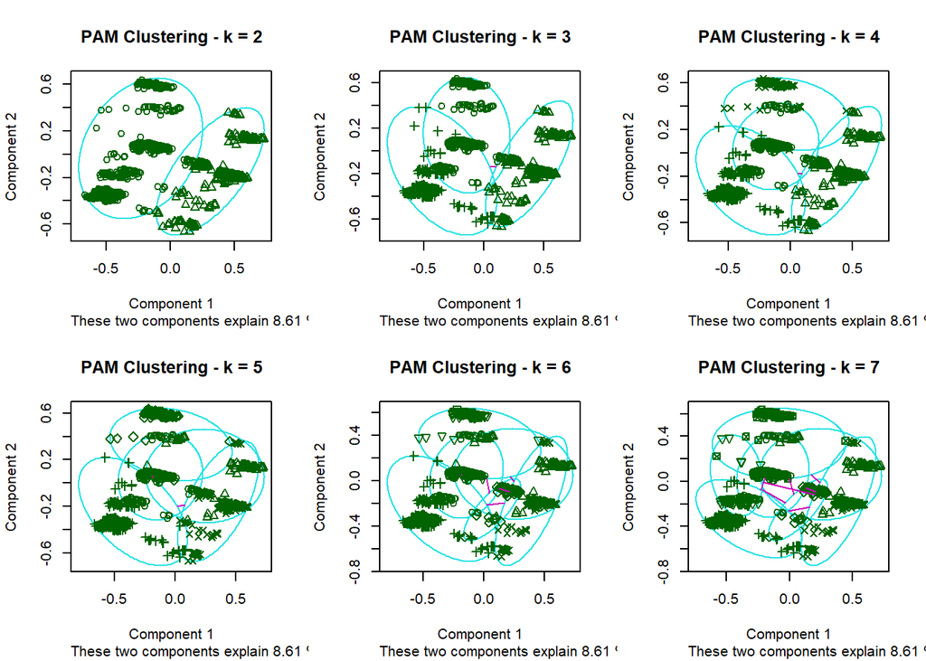

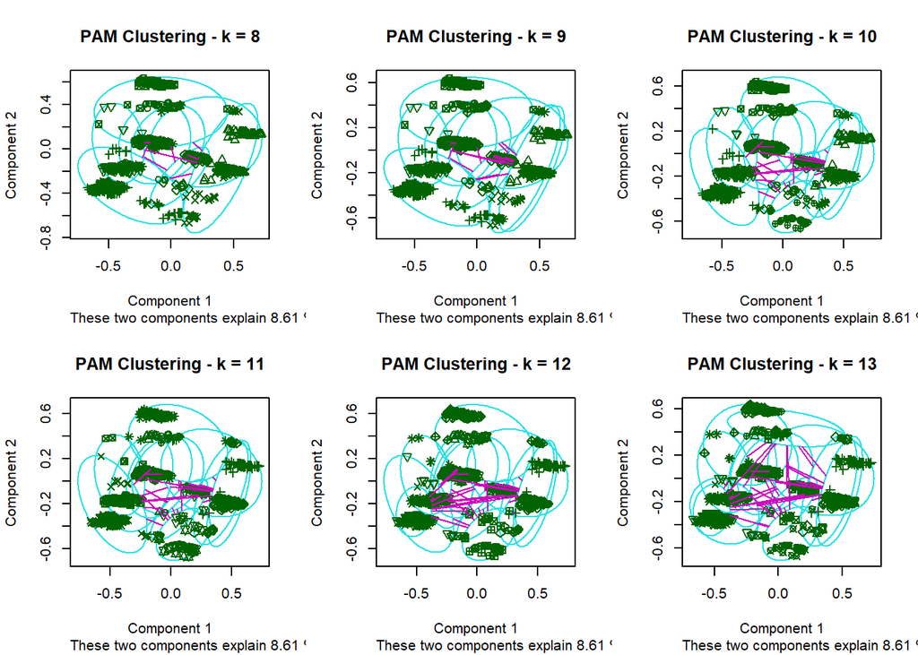

| k | Silhouette_Score |
| --- | --- |
| 2 | 0.3646174 |
| 3 | 0.3981514 |
| 4 | 0.4070522 |
| 5 | 0.4385782 |
| 6 | 0.4762566 |
| 7 | 0.5041751 |
| 8 | 0.4369303 |
| 9 | 0.3860533 |
| 10 | 0.4051437 |
| 11 | 0.3961637 |
| 12 | 0.3712465 |
| 13 | 0.3344377 |

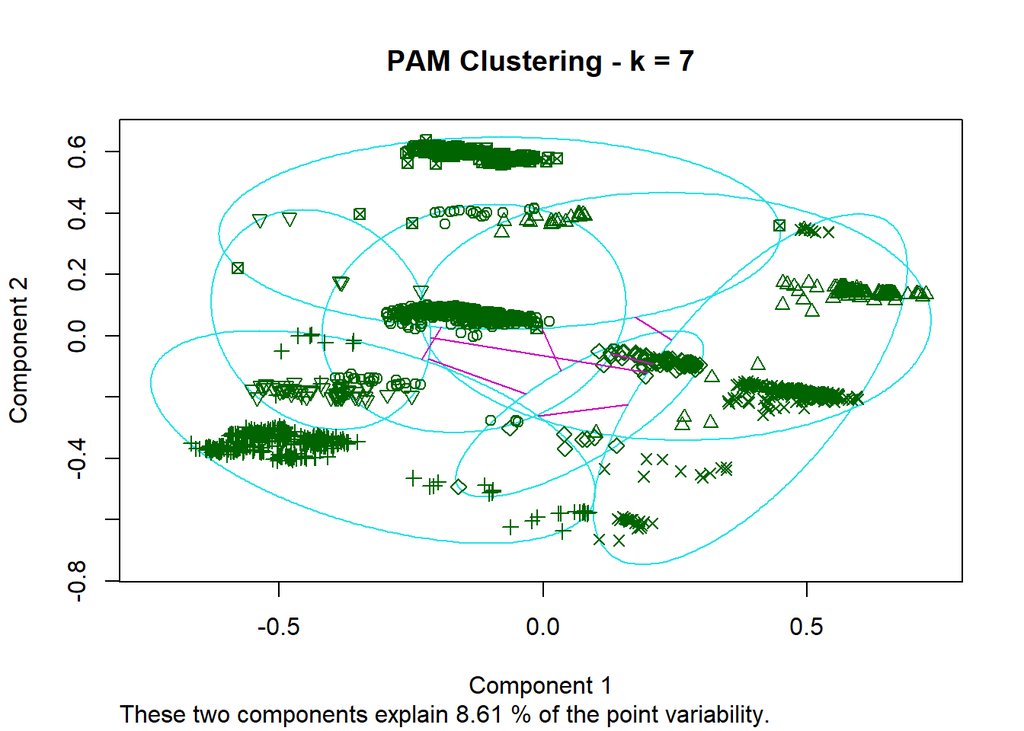

Determining which clusters contain highest cancellations rate

```
  cluster booking.status
1       1            221
2       2             66
3       3            129
4       4            125
5       5             15
6       6             24
7       7             98
```

```
  cluster booking.status
1       1      0.3695652
2       2      0.4313725
3       3      0.3816568
4       4      0.2808989
5       5      0.1250000
6       6      0.4000000
7       7      0.3426573
```

Cluster Profiles

| cluster | cancellation_rate | lead.time_mean | number.of.adults_mean | number.of.children_mean | total.nights_mean | special.requests_mean | average.price_mean | market.segment.type_mode | room.type_mode | type.of.meal_mode |
| --- | --- | --- | --- | --- | --- | --- | --- | --- | --- | --- |
| 1 | 36.96 | 79.37 | 1.83 | 0.13 | 3.17 | 0.90 | 101.98 | Online | Room_Type 1 | Meal Plan 1 |
| 2 | 43.14 | 130.92 | 1.83 | 0.03 | 2.63 | 0.22 | 107.75 | Offline | Room_Type 1 | Meal Plan 2 |
| 3 | 38.17 | 66.35 | 2.21 | 0.05 | 3.59 | 0.94 | 128.55 | Online | Room_Type 4 | Meal Plan 1 |
| 4 | 28.09 | 116.81 | 1.78 | 0.01 | 3.05 | 0.16 | 86.81 | Offline | Room_Type 1 | Meal Plan 1 |
| 5 | 12.50 | 18.13 | 1.29 | 0.00 | 2.07 | 0.26 | 77.56 | Corporate | Room_Type 1 | Meal Plan 1 |
| 6 | 40.00 | 68.75 | 1.68 | 1.85 | 3.00 | 0.98 | 167.42 | Online | Room_Type 6 | Meal Plan 1 |
| 7 | 34.27 | 64.32 | 1.87 | 0.01 | 2.86 | 0.72 | 92.90 | Online | Room_Type 1 | Not Selected |

The summary table above shows that Cluster 2 has the highest cancellation rate, at around 43%, cluster 6 is not far off, at 40%. CLuster 2 is accompanied by the longest time between booking and arrival (130 days) , which may help explain the cancellations. It also has relatively few special requests (0.22 on average) and is primarily associated with the Offline market segment.

Unlike Cluster 2, in Cluster 6 the average lead time is considerably shorter (68.75 days), but it stands out for having the highest average number of children (1.85), the highest average price (167.42), and almost one special request per booking. It associated with the Online segment.

### 3. Hierarchical Clustering

We proceed with hierarchical clustering using Ward’s agglomerative method because it is also suitable for the data used here.

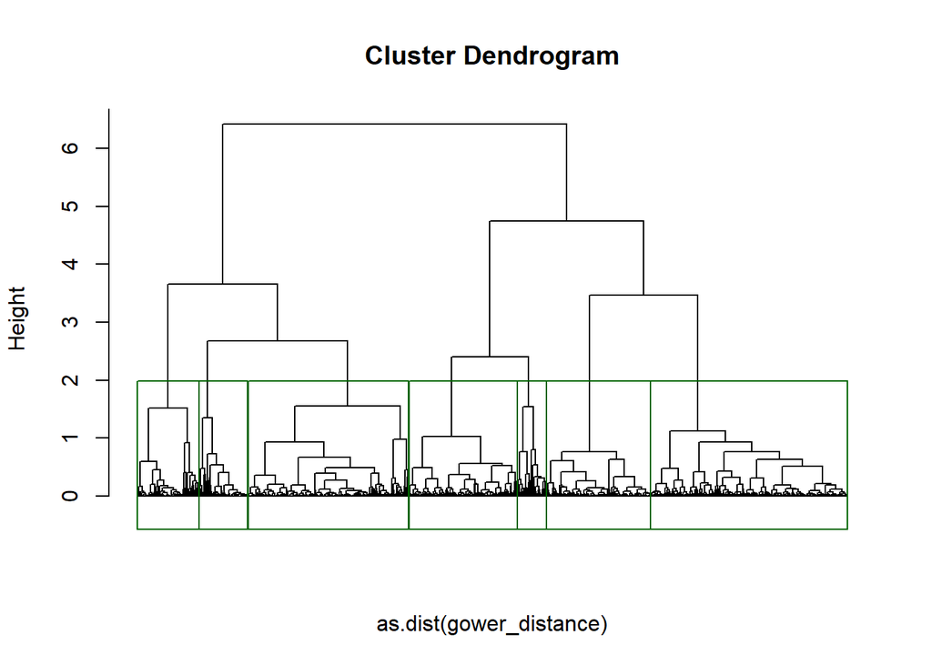

are already well separated, and therefore the clustering process should have been stopped earlier.

In this case, the four largest jumps occur approximately above the value 2.5 (visually, around 2.7).

For testing, we use the heights (1, 1.5, 2, 2.5, 3, 3.5, 4, 4.5, 5).

| Height | Silhouette_Score |
| --- | --- |
| 1.0 | 0.4439252 |
| 1.5 | 0.5368415 |
| 2.0 | 0.5022764 |
| 2.5 | 0.4726590 |
| 3.0 | 0.4271084 |
| 3.5 | 0.4032286 |
| 4.0 | 0.3666924 |
| 4.5 | 0.3666924 |
| 5.0 | 0.3431075 |

A height of 1.5 produces the highest silhouette score (0.5368415), corresponding to 10 clusters. However, this results in several clusters of relatively small size, so the immediately preceding solution is preferred, with a silhouette score of 0.5022764 and 7 clusters. This is also consistent with the PAM result.

```
         1          2          3          4          5          6          7
0.10724984 0.10934179 0.11290856 0.09165958 0.08418756 0.18556319 0.07348085
```

```
         1          2          3          4          5          6          7
0.08888983 0.13869613 0.09173613 0.09941927 0.12581262 0.22094578 0.07595310
```

We observe that, on average, the PAM clusters have lower cohesion values than the hierarchical clusters, indicating that PAM creates tighter, more compact clusters.

Cluster Profiles

| cluster_2 | cancellation_rate | lead.time_mean | number.of.adults_mean | number.of.children_mean | total.nights_mean | special.requests_mean | average.price_mean | market.segment.type_mode | room.type_mode | type.of.meal_mode |
| --- | --- | --- | --- | --- | --- | --- | --- | --- | --- | --- |
| 1 | 0.37 | 77.18 | 1.82 | 0.13 | 3.17 | 0.88 | 102.68 | Online | Room_Type 1 | Meal Plan 1 |
| 2 | 0.44 | 129.25 | 1.86 | 0.04 | 2.84 | 0.37 | 113.60 | Offline | Room_Type 1 | Meal Plan 2 |
| 3 | 0.41 | 69.82 | 2.24 | 0.05 | 3.60 | 0.91 | 131.33 | Online | Room_Type 4 | Meal Plan 1 |
| 4 | 0.28 | 115.69 | 1.78 | 0.02 | 3.08 | 0.22 | 87.35 | Offline | Room_Type 1 | Meal Plan 1 |
| 5 | 0.12 | 16.70 | 1.35 | 0.00 | 2.02 | 0.33 | 70.67 | Corporate | Room_Type 1 | Meal Plan 1 |
| 6 | 0.38 | 80.09 | 1.80 | 1.35 | 3.00 | 0.95 | 147.77 | Online | Room_Type 6 | Meal Plan 1 |
| 7 | 0.34 | 63.78 | 1.87 | 0.01 | 2.90 | 0.70 | 92.81 | Online | Room_Type 1 | Not Selected |

### 4.Clustering Methods comparison

Finally, the Rand statistic and Jaccard coefficient metrics are used.

```
               metric     value
1          Rand Index 0.9693677
2 Adjusted Rand Index 0.9013918
3 Jaccard Coefficient 1.0000000
```

The similarity between the two clustering methods is extremely high. The Rand (0.969), Adjusted Rand (0.901), and Jaccard (1.0) indices indicate that PAM and hierarchical clustering produce an almost identical allocation across the 7 clusters. Although PAM performs better according to the cohesion and separation criteria, the two methods are highly consistent with each other, confirming the stability of the structure in the data.